# Multiple Sequence Alignment and Tree Construction

Sonia Flores

## Introduction

Studies in molecular evolution and genetics often explore how regions of DNA or genes are conserved or change within a species; these DNA sequences may also be conserved among other species of organisms. Phylogenies then display how organisms within a species or among various species relate to each other based on differences and similarities within a given DNA region.

R contains several packages that are capable of performing the tasks necessary for Multiple Sequence Alignments and Phylogeny construction. We will demonstrate these capabilities by aligning and building phylogenies using some genes conserved among birds to display their relationships to each other.

## Methods

### The Organisms

Bird species were chosen to represent as many classes as possible beneath the order Aves. The genes picked for this study are mitochondrial genes known to be conserved among Eukaryotic organisms. These bird species and genes were also picked based on a previous phylogenetic study utilzing mitochondrial genes to study the early history of Modern Birds, though for this project we will be mainly looking at two infraclasses: Palaeognathae (“Basal” birds) and Neognathae which contain the majority of living birds.

Organisms in the outgroup include the American Alligator, Red-Eared Slider, Prairie Rattlesnake, and Eastern Opossum. Alligators share common ancestry with birds, while turtles share an ancestor with crocodylians, but not birds.

### R Packages

The following packages were used for reading DNA data, multiple sequence alignment, and tree construction:

```r
library(tidyverse)
library(BiocManager)
library(ape)
library(phangorn)
library(Biostrings)
library(ggtree)
library(msa)
library(ggmsa)
library(ShortRead)
```

### Sequence clean up

Sequences were collected from NCBI’s Genbank database as FASTA files. These files include the accession number for the genes, the species descriptor and a descriptor for the sequence data such as the name of the genes. Files were read together into R using ShortRead, with some clean up done on the names to leave only the species name and a numerical identifier to prevent redundancy for each sequence.

```r
seqs<-ShortRead::readFasta(c(f1,f2,f3))

seqs@id<-
  paste0(
    seqs@id %>%
      as.character() %>%
      str_split(" ") %>%
      map_chr(2),
    " ",
    seqs@id %>%
      str_split(" ") %>%
      map_chr(3)
  ) %>% BStringSet()

seqs@id

ShortRead::writeFasta(object = seqs, file = "./Data/Cleaned/sequences_16s.fasta", mode ="w")
sequences<- Biostrings::readDNAStringSet("./Data/Cleaned/sequences_16s.fasta")

sequences_s<- ShortRead::readFasta("./Data/Cleaned/sequences_16s.fasta")
newids <- BStringSet(paste0(sequences_s@id, "_",1:length(sequences_s)))
sequences_s@id <- newids
sequences_s@id

writeFasta(sequences_s,"./Data/Cleaned/sequences_nonredundant16s.fasta")
```

These files were saved into their own FASTA files.

### Multiple Sequence Alignment

These new FASTA files were loaded into R in a DNAStringSet format, where Multiple Sequence Alignment could be performed through the msa package. msa contains several methods of aligning sequences: ClustalOmega, ClustalW, and MUSCLE. Each alignment type also utilize various methods of clustering the alignments, however due to known issues with clustering in msa, only the Neighbor Joining method was used.

```r
cleanseq<- Biostrings::readDNAStringSet("./Data/Cleaned/sequences_nonredundant16s.fasta")

alignmentM<-msa::msaMuscle(inputSeqs=cleanseq, cluster="neighborjoining", type="dna", order="input")
```

The resulting alignments are displayed in a MultipleSequenceAlignment format, though for Phylogeny Construction the alignments were saved under new FASTA files.

```r
ShortRead::writeFasta(DNAStringSet(alignmentM),"./Data/Cleaned/alignmentM_16s.fasta")
```

Images of the alignments were constructed using ggmsa to display a clean alignment for viewing. Because many alignments were too long to display in their entirety, only a section of each alignment was displayed.

```r
alignM16s<- read.FASTA("./Data/Cleaned/alignmentM_16s.fasta")
ggmsa(alignM16s, 250, 375, color = "Chemistry_NT", font = "DroidSansMono",
      char_width = 0.7, seq_name = TRUE, border=NA, by_conservation=TRUE)
```

### Construction of Phylogenies

Tree construction was done mainly through phangorn. The aligned sequences saved as FASTA files were read into R first as a DNAMultipleAlignment file, then a phyDat file. Distance matrices were applied to phyDat files, then were built into a simple neighbor-joining tree. Before moving on, the ape package was used to root the trees to the outgroup.

```r
alignM16sSet<- readDNAMultipleAlignment("./Data/Cleaned/alignmentM_16s.fasta")

align_phyDatM<-msa::msaConvert(x=alignM16sSet, type= "phangorn::phyDat")

phydist<-dist.ml(align_phyDatM)


nj<- phangorn::NJ(phydist)

ape::is.rooted(nj)
root_nj<-ape::root(phy = nj,"Didelphis virginiana_51",
                   resolve.root=TRUE)
```

From here, bootstrap values were added to the trees and re-rooted if necessary. Bootstrapping was repeated 100 times for each tree. Boostrapping is a test that utilizes random sampling and resampling to test how often the same branch is observed on a phylogenetic tree. A score is given to each node on a branch to show how many times out of 100 that particular branch is seen. Scores between 90 to 100 are good indicators that the branch is well supported. Scores below 90 have less confidence in supporting the indicated relationship.

```r
fit <- pml(root_nj, align_phyDatM)
fit <- optim.pml(fit, rearrangement="NNI")

bs <- bootstrap.pml(fit, bs=100, optNni=TRUE)
treeBS <- plotBS(fit$tree, bs, type ="phylogram")

root_bs<- ape::root(phy = treeBS,"Didelphis virginiana_51", resolve.root=TRUE)
plotBS(root_bs, type="phylogram")
```

Finally, trees were cleaned using ggtree to display the trees in a readable format while also highlighting parts of the tree.

```r
tree <- groupClade(root_bs, c(83,55,90))
p <- ggtree(tree, aes(color=group), branch.length="none") +
  scale_color_manual(values=c("black","firebrick", "steelblue", "orchid"))+
  geom_tiplab(alignt=FALSE, size=3)+
  geom_treescale(fontsize=3)+
  ggtree::geom_nodelab(node= 'internal')
```

## Results

### Multiple Sequence Alignments

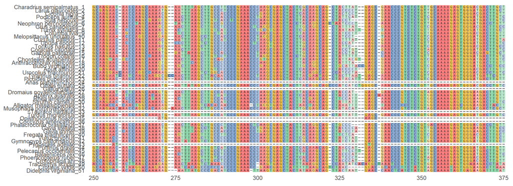

A section of the aligned 16s Gene sequences in birds and outgroup animals

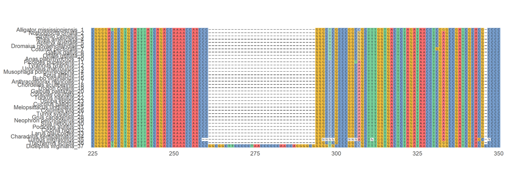

A section of the aligned 18s Gene sequences in birds and outgroup animals

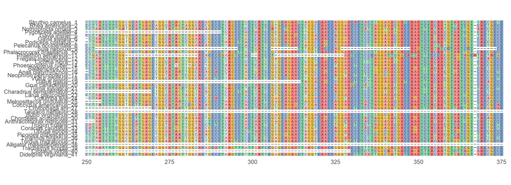

A section of the aligned Cytochrome Oxidase I Gene sequences in birds and outgroup animals

While these images only display a given 125 base pair long section of the alignments, we can see some significant overlap between most sequences, as well as highly conserved sections of the sequences across all species as denoted by the bold coloration of the cells. The colorless dashed cells indicate gaps in the alignment.

### Phylogenies

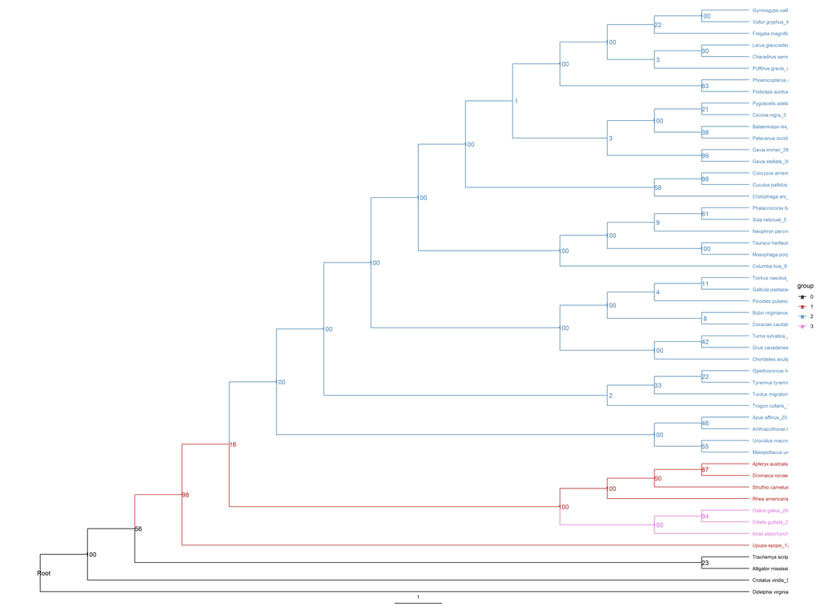

Bootstrapped Maximum Likelihood Tree from 16s Subunit Gene

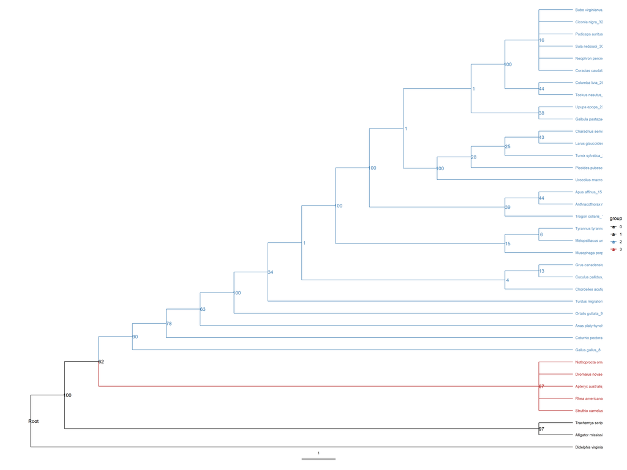

Bootstrapped Maximum Likelihood Tree from 18s Subunit Gene

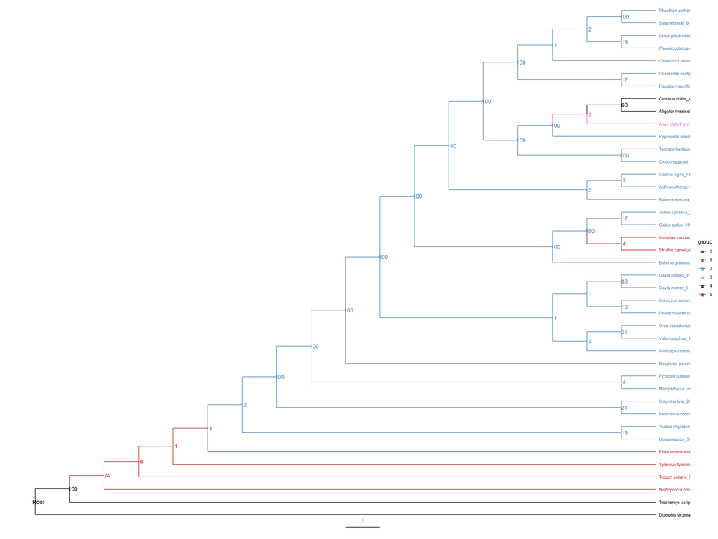

Bootstrapped Maximum Likelihood Tree from Cytochrome Oxidase I Gene

## Conclusions

R has access to many useful sequence alignment tools for molecular and genetic analyses, as well as many ways to construct and format trees to display the relationships derived from those analyses. The msa package is one of the easier alignment tools to use, however it has significant limitations with what types of clustering it can do, as well as technical issues with certain alignment types. As mentioned earlier, only the Neighbor Joining method of clustering was available due to known errors in msa when using UPGMA clustering methods. Alignment using msa also suffered from memory leak issues when aligning more than 50 sequences or very long sequences, especially when large gaps were present.

The msa package is a good introduction to sequence alignment in R, however for serious studies using sequence alignment, other alignment packages are available for use with better ongoing support and options for clustering.

While the msa package had its issues with aligning the sequences, the sequences themselves may also play a part into why the alignments and resulting trees from those alignmnets displayed strange relationships between organisms. While NCBI is an expansive depository for DNA, RNA, and protein sequences, it is not well curated and some sequences may be erroneously named or misrepresentative of the gene or proteins they describe.

## Reference to Study

Marcel van Tuinen, Charles G. Sibley, S. Blair Hedges, The Early History of Modern Birds Inferred from DNA Sequences of Nuclear and Mitochondrial Ribosomal Genes, Molecular Biology and Evolution, Volume 17, Issue 3, March 2000, Pages 451–457, https://doi.org/10.1093/oxfordjournals.molbev.a026324